# COSC-523: Lab 02

**Daniel Carter**

[Notebook Link](https://colab.research.google.com/drive/18TNSSo46rPA9f6PG9BiY4T9uixKUB3lA#scrollTo=EVce2wCod0GJ)

## Getting Started

Follow the instructions below to copy this notebook and to perform some initial setup.

1. Copy this notebook by selecting `File > Save a copy in Drive`.
2. A new window should open for the copied notebook. Move the new notebook to your course folder in Google Drive by selecting `File > Move` and then selecting the desired folder.
3. Update the name of the notebook by removing "Copy of" and replacing "Username" with your actual username.
4. Update the first cell in the notebook by specifying your course number (423 or 523) and by replacing "**Student Name**" with your actual name.
5. Do not edit the line that says `PLACEHOLDER_FOR_NOTEBOOK_LINK`. This will be used by the [Notebook Renderer](https://colab.research.google.com/drive/1CJTipys46ldZxJFwnt7XbdjQUfkmoXeU?usp=sharing) tool to insert a link to your Colab notebook.
6. Enable link sharing for your notebook.

# Part 1: Image segmentation using Histograms

Load the Cactus image and plot its histogram. Display both the original image and the histogram with suitable titles and axes marked

Observe this histogram and according to this histogram, pick 2 threshold values

Threshold value 1: This value should make sure that the sky is not black, or has any black pixels

Threshold value 2: This value should make sure that the mountains in the distance are visible, even if the sky turns blackish

Use this threshold value to binarize the image and display the new segmented image (its just binarized, don't get confused with watershed segmentation) with appropriate title.

Mention in a comment which threshold values did you pick.

Mention in a comment, what did you learn from this exercise, do you think its easy to pick one threshold always?

Your output image should be displayed side by side the original image ( you will have total 4 images, first original side by side with 1st threshold and second, with original side by side with 2nd threshold.

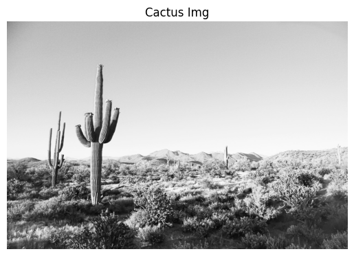

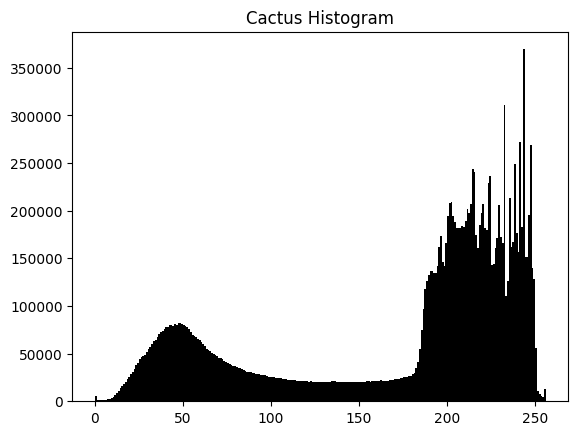

```python
import cv2
import numpy as np
import matplotlib.pyplot as plt

#Load cactus.jpg image using cv2
cactus_img = cv2.imread('cactus.jpg')

# Display the Lena image in RGB
plt.imshow(cactus_img, cmap='gray')
plt.title('Cactus Img')
plt.axis('off')
plt.show()

#plot histogram of original image
plt.hist(cactus_img.ravel(),256,[0,256],color='black')
plt.title('Cactus Histogram')
plt.show()
```

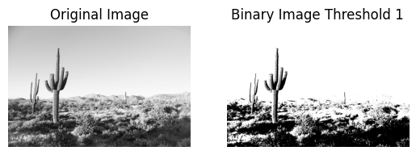

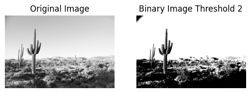

```python
#create image segmentation func
def image_segmentation(img, threshold):
  #apply threshold
  _, binary_img = cv2.threshold(img, threshold, 255, cv2.THRESH_BINARY)
  return binary_img

#First image should make sure the sky has no black pixels
threshold = 100
binary_img1 = image_segmentation(cactus_img, threshold)
#plot original img and first threshold next to each other
plt.subplot(1, 2, 1)
plt.imshow(cactus_img, cmap='gray')
plt.title('Original Image')
plt.axis('off')
plt.subplot(1, 2, 2)
plt.imshow(binary_img1, cmap='gray')
plt.title('Binary Image Threshold 1')
plt.axis('off')
plt.show()

#Second image makes sure that the mountains are visible even if the sky is a little black
threshold = 175
binary_img2 = image_segmentation(cactus_img, threshold)
#plot original img and second threshold next to each other
plt.subplot(1, 2, 1)
plt.imshow(cactus_img, cmap='gray')
plt.title('Original Image')
plt.axis('off')
plt.subplot(1, 2, 2)
plt.imshow(binary_img2, cmap='gray')
plt.title('Binary Image Threshold 2')
plt.axis('off')
plt.show()
```

# Thresholds picked

- Threshold one = 100
- Threshold two = 175

# Experience Learned

## I don't think that it is easy to always pick one threshold. I think the threshold needs to change depending on what you are trying to highlight in the image you are working with

# Part 2: Noise removal

Load the Gaussian Noise image.

Take steps to remove this noise (its discussed in one of the lessons)

After taking the last step, you might want to try something called the median filter in OpenCV (you can use Google to use the syntax)

Display original image and corrected images (there should be 2 corrected images). You won't get a perfect image but it will be much better.

What did you learn about the median filter? You can answer this as a comment.

[figure not shown]

```python
#load gaussian noise image
gaussian_noise_img = cv2.imread('gaussian noise.png')


#remove noise using gaussian method defined in lesson

#create function similar to module to add noise to the img
def add_gaussian_noise(img, mean, std_dev):
    h, w, c = img.shape
    noise = np.random.normal(mean, std_dev, (h,w,c))
    # Convert image to float32 for addition
    img_float = img.astype(np.float32)
    # Add noise to the float image
    noisy_img_float = cv2.add(img_float, noise.astype(np.float32))
    # Clip values to be within the valid range [0, 255] before converting back to uint8
    noisy_img = np.clip(noisy_img_float, 0, 255).astype(np.uint8)
    return noisy_img
#define guassian blur function
def gaussian_blur(img, kernel_size):
    blurred_img = cv2.GaussianBlur(img, (kernel_size, kernel_size), 0)
    return blurred_img
#add guassian noise to img
noisy_img = add_gaussian_noise(gaussian_noise_img, 0, 25)
#apply blur
blurred_img = gaussian_blur(noisy_img, 5)

#apply median filter. Define function to use OpenCV median filter
def median_filter(img, kernel_size):
    filtered_img = cv2.medianBlur(img, kernel_size)
    return filtered_img

#apply median filter
filtered_img = median_filter(gaussian_noise_img, 5)

#plot original img, gaussian img, and median img
plt.figure(figsize=(15, 5))
plt.subplot(1, 3, 1)
plt.imshow(gaussian_noise_img, cmap='gray')
plt.title('Original Image')
plt.axis('off')
plt.subplot(1, 3, 2)
plt.imshow(blurred_img, cmap='gray')
plt.title('Gaussian Blur Image')
plt.axis('off')
plt.subplot(1, 3, 3)
plt.imshow(filtered_img, cmap='gray')
plt.title('Median Image')
plt.axis('off')
plt.show()
```

# What did I learn about the median filter

## I learned that it is very similar to the Gaussian Blur function taught in the lesson but in this case, it actually produced a much cleaner result. Not sure if I did something wrong here but it looks much better

# Part 3: Contour Detection

Load the cards image.

Perform Contour Detection on it. Part of this code is given to you.

Make sure the contour colors are blue and not green

Aftre finshing this, you might have to play with the parameters to find a cleaner looking contour

Display the original image side by side with the contour image

[figure not shown]

```python
# Load the image
cards_img = cv2.imread('cards.webp')



# Convert the image to grayscale
gray_image = cv2.cvtColor(cards_img, cv2.COLOR_BGR2GRAY)

# Apply Canny edge detection
edges = cv2.Canny(gray_image, 20, 45)


# Find contours
# Find contours
contours, _ = cv2.findContours(edges, cv2.RETR_EXTERNAL, cv2.CHAIN_APPROX_SIMPLE)
# Draw contours on the original image
contour_image = cards_img.copy()
cv2.drawContours(contour_image, contours, -1, (0, 255, 0), 2)

# Display the original image with contours
plt.figure(figsize=(10, 10))
plt.subplot(1, 2, 1)
plt.imshow(cv2.cvtColor(cards_img, cv2.COLOR_BGR2RGB))
plt.title('Original Image')
plt.axis('off')

plt.subplot(1, 2, 2)
plt.imshow(cv2.cvtColor(contour_image, cv2.COLOR_BGR2RGB))
plt.title('Image with Contours')
plt.axis('off')

plt.show()
```

# Part 4: Histogram Equalization

Load the peppers image.

Perform RGB histogram equalization on it

Display both images side by side.

You will notice that histogram equalization wasn't able to get rid of the tint that the image had, in fact it now looks like the image has a blue tint.

Now, modify your code to see, if you can selectively equalize only one channel and keep the rest as is.

Hint: Equalizing one of the channels and keeping the rest as is, will fix the problem and give you a better equalized image.

Mention which channel you chose to equalize.

Display the final result side by side with the original image with the correct titles

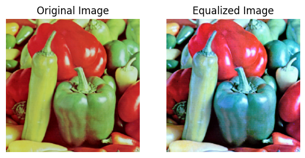

```python
#load the peppers png
peppers_img = cv2.imread('peppers.png')
peppers_img_rgb = cv2.cvtColor(peppers_img, cv2.COLOR_BGR2RGB)

#perform RGB histogram equalization to img
channels = cv2.split(peppers_img_rgb)
equalized_channels = []
for channel in channels:
    equalized_channels.append(cv2.equalizeHist(channel))
equalized_rgb = cv2.merge(equalized_channels)

#plot original and new picture
plt.subplot(1, 2, 1)
plt.imshow(peppers_img_rgb)
plt.title('Original Image')
plt.axis('off')
plt.subplot(1, 2, 2)
plt.imshow(equalized_rgb)
plt.title('Equalized Image')
plt.axis('off')
plt.show()
```

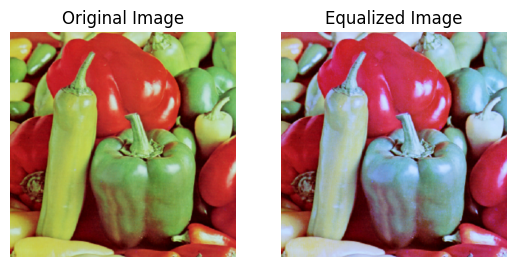

```python
#Just equalize one of the channels instead of all of them
single_channel = 2
channels = cv2.split(peppers_img_rgb)
equalized_channels = []
for i, channel in enumerate(channels):
    if i == single_channel:
        equalized_channels.append(cv2.equalizeHist(channel))
    else:
        equalized_channels.append(channel)
equalized_blue_channel = cv2.merge(equalized_channels)

#plot original and new picture
plt.subplot(1, 2, 1)
plt.imshow(peppers_img_rgb)
plt.title('Original Image')
plt.axis('off')
plt
plt.subplot(1, 2, 2)
plt.imshow(equalized_blue_channel)
plt.title('Equalized Image')
plt.axis('off')
plt.show()
```

# What channel did you choose?

## I chose the blue channel to try to equalize

# Part 5: Watershed Algorithm Segmentation

Load the coins image.

Apply the watershed algorithm on this image and display the original with the segmented image

Do you see all the coins segmented?

If some coins are left, modify the the code to make sure that all coins are segmented.

Display final results and mention what did you change and why.

Explore Color Models:

Convert the image to different color models: Grayscale HSV (Hue, Saturation, Value) Visualize each channel (R, G, B for RGB and H, S, V for HSV) separately. Analyze Pixel Values:

Select a few pixels from the image and display their values in RGB, HSV, and Grayscale formats. Visualize Results:

Display the original image, the converted images, and the individual channels.

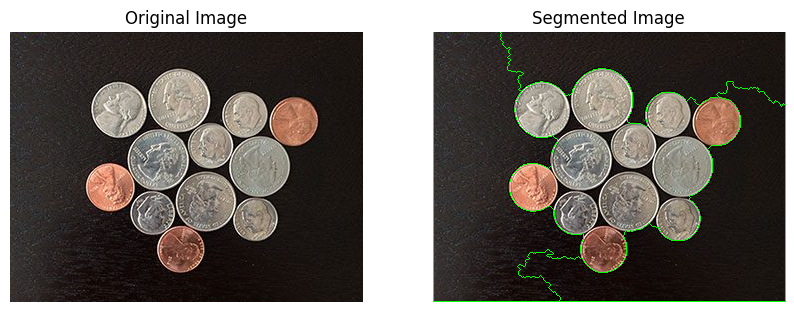

```python
#load the coins png
coins_img = cv2.imread('coins.png')

#create watershed alg similar to one in module
def watershed_segmentation(img):
    # Convert the image to grayscale
    gray_image = cv2.cvtColor(img, cv2.COLOR_BGR2GRAY)
    #apply gaussian blur
    blurred = cv2.GaussianBlur(gray_image, (5, 5), 0)
    # Apply thresholding
    _, thresholded = cv2.threshold(blurred, 0, 255, cv2.THRESH_BINARY_INV + cv2.THRESH_OTSU)
    # Morphological operations
    kernel = np.ones((3, 3), np.uint8)
    opening = cv2.morphologyEx(thresholded, cv2.MORPH_OPEN, kernel, iterations=3)
    #Sure background
    sure_bg = cv2.dilate(opening, kernel, iterations=3)
    #Sure foreground
    dist_transform = cv2.distanceTransform(opening, cv2.DIST_L2, 5)
    _, sure_fg = cv2.threshold(dist_transform, 0.5 * dist_transform.max(), 255, 0)
    #Unknown region
    sure_fg = np.uint8(sure_fg)
    unknown = cv2.subtract(sure_bg, sure_fg)
    # Marker labelling
    _, markers = cv2.connectedComponents(sure_fg)
    # Add one to all labels so that sure background is not 0, but 1
    markers = markers + 1
    # Now, mark the region of unknown with zero
    markers[unknown == 255] = 0
    # Apply watershed
    result = img.copy()
    cv2.watershed(result, markers)
    result[markers == -1] = [0, 255,0]
    return result
#Apply watershed to coins image
segmented_coins = watershed_segmentation(coins_img)
#plot original and segmented next to each other
plt.figure(figsize=(10, 5))
plt.subplot(1, 2, 1)
plt.imshow(cv2.cvtColor(coins_img, cv2.COLOR_BGR2RGB))
plt.title('Original Image')
plt.axis('off')
plt.subplot(1, 2, 2)
plt.imshow(cv2.cvtColor(segmented_coins, cv2.COLOR_BGR2RGB))
plt.title('Segmented Image')
plt.axis('off')
plt.show()
```

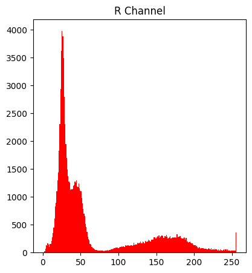

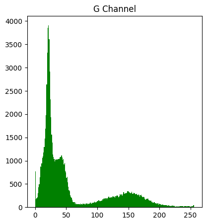

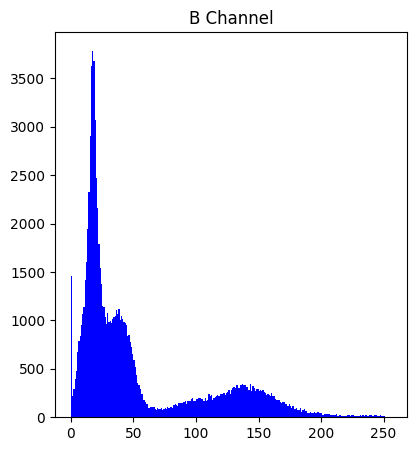

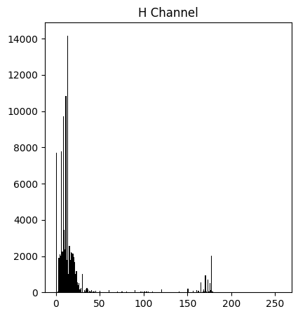

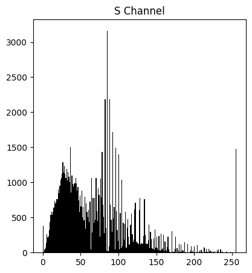

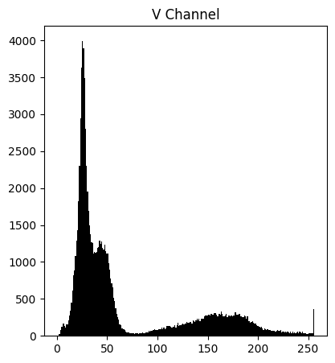

```python
#Convert the image to different color models: Grayscale HSV (Hue, Saturation, Value) Visualize each channel (R, G, B for RGB and H, S, V for HSV) separately
gray_img = cv2.cvtColor(coins_img, cv2.COLOR_BGR2GRAY)
hsv_img = cv2.cvtColor(coins_img, cv2.COLOR_BGR2HSV)
#visualize each channel separately
r_channel = coins_img[:, :, 2]
g_channel = coins_img[:, :, 1]
b_channel = coins_img[:, :, 0]
h_channel = hsv_img[:, :, 0]
s_channel = hsv_img[:, :, 1]
v_channel = hsv_img[:, :, 2]

#create histograms for each channel
def create_histogram(img, title, color):
    plt.hist(img.ravel(), 256, [0, 256], color=color)
    plt.title(title)
    plt.show()
for channel, title, color in zip([r_channel, g_channel, b_channel, h_channel, s_channel, v_channel], ['R Channel', 'G Channel', 'B Channel', 'H Channel', 'S Channel', 'V Channel'], ['red', 'green', 'blue', 'black', 'black', 'black']):
    plt.figure(figsize=(10, 5))
    plt.subplot(1, 2, 1)
    create_histogram(channel, title, color)
```

[output not shown]

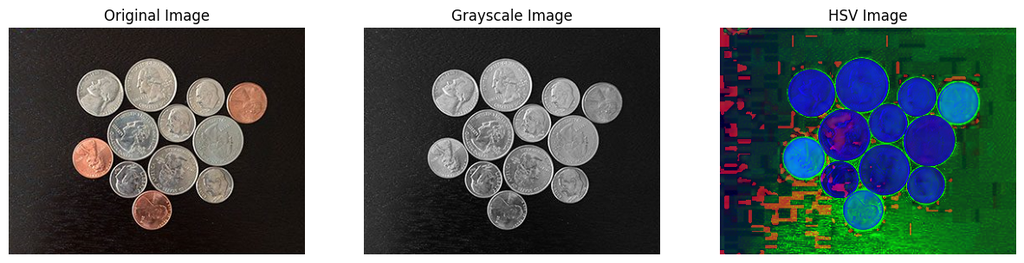

```python
#Display the converted images and the original image
plt.figure(figsize=(15, 10))
plt.subplot(2, 3, 1)
plt.imshow(cv2.cvtColor(coins_img, cv2.COLOR_BGR2RGB))
plt.title('Original Image')
plt.axis('off')
plt.subplot(2, 3, 2)
plt.imshow(gray_img, cmap='gray')
plt.title('Grayscale Image')
plt.axis('off')
plt.subplot(2, 3, 3)
plt.imshow(hsv_img)
plt.title('HSV Image')
plt.axis('off')
```

# Submission Instructions

1. Perform a Restart and Run All by clicking **Tools > Restart session and run all**.
2. Copy the link to your notebook by clicking **Share > Copy Link**.
3. Paste the copied link into the `notebook_url` field in the [Notebook Renderer](https://colab.research.google.com/drive/1CJTipys46ldZxJFwnt7XbdjQUfkmoXeU?usp=sharing) tool and then execute the cell to render the notebook.
4. The Notebook Renderer will open up a save file dialog. Save the resulting HTML file yo your local machine.
5. Submit the HTML file to Canvas.